# ANSWERS: Working with untidy and tidy data

Data Science for Biologists, Spring 2020

Poonam Shah

# Questions

#### Preface Question

Look at the YAML front matter: there is something NEW! Read about params [here](https://rmarkdown.rstudio.com/lesson-6.html). In this case we set a global parameter for the RMarkdown file that corresponds to the path where data lives! We can proceed to use this as a variable like so (always `params$`, like a column in a data frame!). Use this variable for your paths, e.g. `read_csv(paste0(params$data_path, <NAMEOFFILE>))`

```r
params$data_path
```

```
## [1] "data/"
```

#### Question 1

```r
# Code chunk to read in and examine the data with head()

measle <- read_csv(paste0(params$data_path, "mcv_immunized_percent_of_one_year_olds.csv"))
head(measle)
```

```
## # A tibble: 6 x 33
##   country `1980` `1981` `1982` `1983` `1984` `1985` `1986` `1987` `1988` `1989`
##   <chr>    <dbl>  <dbl>  <dbl>  <dbl>  <dbl>  <dbl>  <dbl>  <dbl>  <dbl>  <dbl>
## 1 Afghan…     11     NA      8      9     14     14     14     31     34     22
## 2 Albania     90     90     93     96     96     96     96     96     96     96
## 3 Algeria     NA     NA     NA     NA     NA     68     67     73     81     82
## 4 Andorra     NA     NA     NA     NA     NA     NA     NA     NA     NA     NA
## 5 Angola      NA     NA     NA     26     35     44     44     55     56     48
## 6 Antigu…     NA     NA     NA     48     73     69     80     89     95     95
## # … with 22 more variables: `1990` <dbl>, `1991` <dbl>, `1992` <dbl>,
## #   `1993` <dbl>, `1994` <dbl>, `1995` <dbl>, `1996` <dbl>, `1997` <dbl>,
## #   `1998` <dbl>, `1999` <dbl>, `2000` <dbl>, `2001` <dbl>, `2002` <dbl>,
## #   `2003` <dbl>, `2004` <dbl>, `2005` <dbl>, `2006` <dbl>, `2007` <dbl>,
## #   `2008` <dbl>, `2009` <dbl>, `2010` <dbl>, `2011` <dbl>
```

```r
# Code chunk to convert data to tidy
#data and piped into the function
measle %>%
  #pivot_longer untidy to tidy. minus country
  pivot_longer(-country, names_to ="Year", values_to="Percent") -> Measle_data_from_q1 #new variable

head(Measle_data_from_q1)
```

```
## # A tibble: 6 x 3
##   country     Year  Percent
##   <chr>       <chr>   <dbl>
## 1 Afghanistan 1980       11
## 2 Afghanistan 1981       NA
## 3 Afghanistan 1982        8
## 4 Afghanistan 1983        9
## 5 Afghanistan 1984       14
## 6 Afghanistan 1985       14
```

#### Question 2

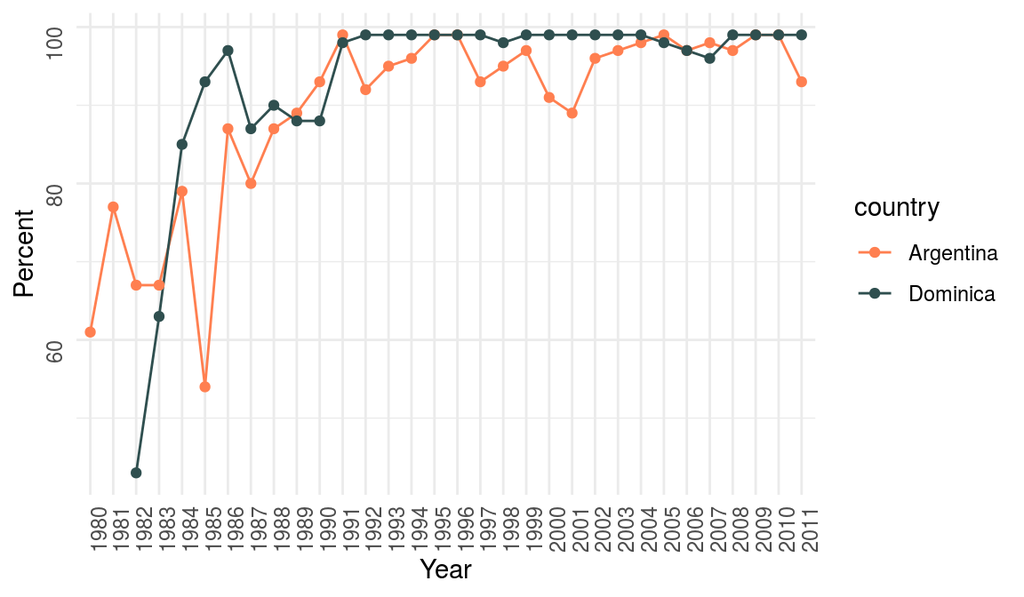

```r
# Code chunk to plot the data
#dataset piped
Measle_data_from_q1 %>%
  #filter and using an array to show both country
  filter(country %in% c("Argentina", "Dominica")) %>%
  #setting up the axis and groups for the line plot
  ggplot(aes(x=Year, y=Percent, color=country, group=country)) +
  #line graph
  geom_line()+
  #the points graph
  geom_point()+
  #clear up the axis
  labs(x="Year", y="Percent")+
  #changed the colors
  scale_color_manual(values = c(color_choice_1,color_choice_2))+
  #changed the angle of the year
  theme(axis.text = element_text(angle = 90))
```

In a few sentences below the figure, discuss the trends you observe.

Dominica started the measle vaccines in 1982 it started even out around 1993. Argentina started measle at 1980. Argentina is uneven in the measle vaccines.

#### Question 3

```r
# Code chunk to read in and examine the data with head()
#reading in the code
Diphtheria_tetanus_pertussis <- read_csv(paste0(params$data_path, "dtp3_immunized_percent_of_one_year_olds.csv"))
#Showing the data
head(Diphtheria_tetanus_pertussis)
```

```
## # A tibble: 6 x 33
##   country `1980` `1981` `1982` `1983` `1984` `1985` `1986` `1987` `1988` `1989`
##   <chr>    <dbl>  <dbl>  <dbl>  <dbl>  <dbl>  <dbl>  <dbl>  <dbl>  <dbl>  <dbl>
## 1 Afghan…      4      3      5      5     16     15     11     25     35     33
## 2 Albania     94     94     95     95     95     96     96     96     96     94
## 3 Algeria     NA     NA     NA     NA     NA     69     73     79     85     87
## 4 Andorra     NA     NA     NA     NA     NA     NA     NA     NA     NA     NA
## 5 Angola      NA     NA     NA      6      8      8     10     10     12     18
## 6 Antigu…     54     79     79     99     94     99     96     97     98     99
## # … with 22 more variables: `1990` <dbl>, `1991` <dbl>, `1992` <dbl>,
## #   `1993` <dbl>, `1994` <dbl>, `1995` <dbl>, `1996` <dbl>, `1997` <dbl>,
## #   `1998` <dbl>, `1999` <dbl>, `2000` <dbl>, `2001` <dbl>, `2002` <dbl>,
## #   `2003` <dbl>, `2004` <dbl>, `2005` <dbl>, `2006` <dbl>, `2007` <dbl>,
## #   `2008` <dbl>, `2009` <dbl>, `2010` <dbl>, `2011` <dbl>
```

```r
# Code chunk to convert data to tidy and combine with question 1 data

#tidying up Diphtheria-tetanus-pertussis
Diphtheria_tetanus_pertussis %>%
pivot_longer(-country, names_to ="Year", values_to="Percent") %>%
  #adding a new column
  mutate(Vaccine = "Diphtheria-tetanus-pertussis" ) -> DTP_tidy

#Adding a new column
Measle_data_from_q1 %>%
  mutate(Vaccine = "Measles") -> Measle_tidy_q3

#combing the dataset
bind_rows(DTP_tidy,Measle_tidy_q3) -> DTP_Mealse_data

#changing year to a char to a dbl
DTP_Mealse_data %>%
mutate(Year = as.numeric(Year)) %>%
#filtering between 2005-2011
filter(between(Year, 2005,2011)) -> DTP_Mealse_2005_2011_data
```

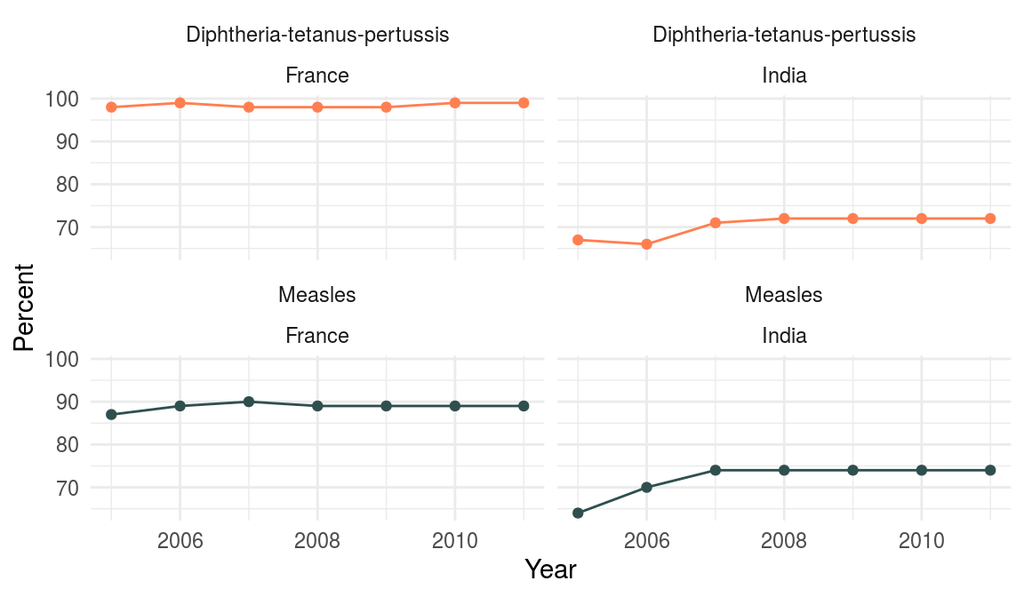

```r
# Code chunk to plot the data
DTP_Mealse_2005_2011_data %>%
  #filter and using an array to show both country
  filter(country %in% c("India", "France")) %>%
  #setting up the axis and groups for the line plot
  ggplot(aes(x=Year, y=Percent, color=Vaccine, group=country)) +
  #line graph
  geom_line()+
  #the points graph
  geom_point() +
  xlim(2005, 2011) +
  facet_wrap(Vaccine~country) +
  scale_color_manual(values = c(color_choice_1,color_choice_2)) +
  theme(legend.position="none")
```

France had a better vaccine rate then India. France is a first world country it would have a better medicine then India. India has a low vaccine rate for both Measles and DTP.

#### Question 4

```r
# Code chunk to read in and examine the data with head()

#reading in the data
seals<-read_csv(paste0(params$data_path, "seals.csv"))
#viewing the data
head(seals)
```

```
## # A tibble: 6 x 3
##    seal feeding oxygen_use
##   <dbl> <chr>        <dbl>
## 1     1 No            42.2
## 2     1 Yes           71
## 3     2 No            51.7
## 4     2 Yes           77.3
## 5     3 No            82.8
## 6     3 Yes           78.6
```

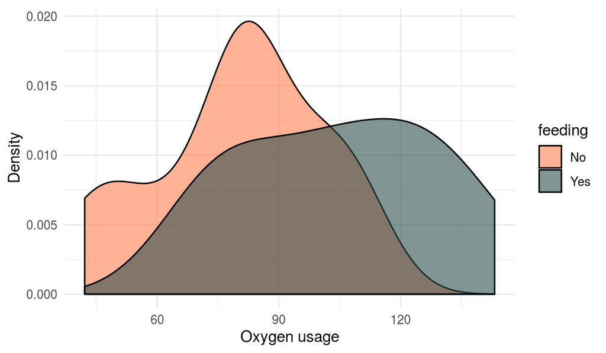

```r
# Density plot with feeding
seals %>%
  #x axis and fill with feeding
  ggplot(aes(x=oxygen_use, fill=feeding)) +
  #density plot
  geom_density(alpha=0.6) +
  #cleaning up the axis
  labs(x="Oxygen usage", y="Density") +
  scale_fill_manual(values = c(color_choice_1,color_choice_2))
```

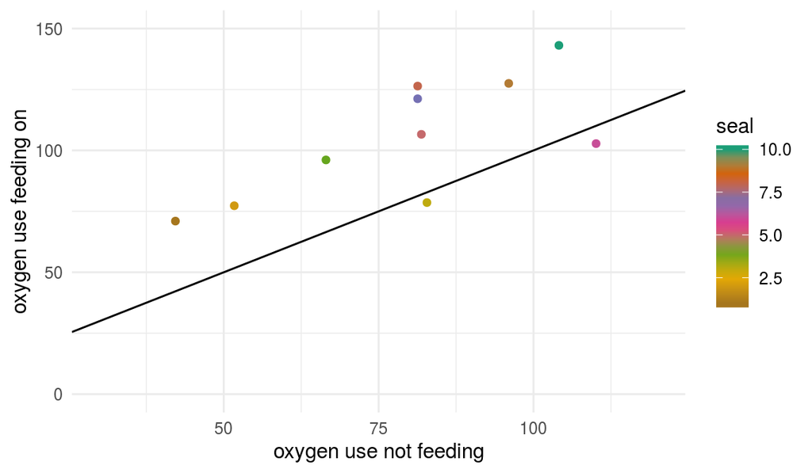

```r
# Code chunk for data un-tidying and scatterplot
seals %>%
  pivot_wider(names_from = feeding, values_from = oxygen_use) %>%
  #renaming the columns
  rename(oxygen_use_not_feeding = No) %>%
  rename(oxygen_use_feeding_on = Yes) -> seals_untidy


seals_untidy %>%
  ggplot(aes(x=oxygen_use_not_feeding, y=oxygen_use_feeding_on)) +
  geom_point(aes( color=seal)) +
  # add reference lines
  geom_abline() +
  #fixing the axis units
  xlim(30,120) +
  ylim(0,150) +
  #making sure every point has a different color
  scale_color_distiller(palette = "Dark2") +
  #clearing up the axis
  labs(x="oxygen use not feeding", y="oxygen use feeding on")
```

In a few sentences below the figure, discuss whether EACH FIGURE shows evidence for the researchers’ prediction.

#### Question 5

```r
#reading in the data
planets <- read_csv2(paste0(params$data_path, "planets.csv"))
```

```
## Using ',' as decimal and '.' as grouping mark. Use read_delim() for more control.
```

```r
#examine the data with head()
head(planets)
```

```
## # A tibble: 6 x 10
##   name  rotation_period orbital_period diameter climate gravity terrain
##   <chr>           <dbl>          <dbl>    <dbl> <chr>   <chr>   <chr>
## 1 Alde…              24            364    12500 temper… 1 stan… grassl…
## 2 Yavi…              24           4818    10200 temper… 1 stan… jungle…
## 3 Hoth               23            549     7200 frozen  1.1 st… tundra…
## 4 Dago…              23            341     8900 murky   N/A     swamp,…
## 5 Besp…              12           5110   118000 temper… 1.5 st… gas gi…
## 6 Endor              18            402     4900 temper… 0.85 s… forest…
## # … with 3 more variables: surface_water <chr>, population <chr>, edited <chr>
```

```r
planets %>%
  #separate the items in the terrain column
  separate_rows(terrain) %>%
  #separate the items in the climate column
  separate_rows(climate) -> planets_tidy
```

#### Question 6

```r
planets_tidy %>%
  #separated the date and time from T
  separate(edited, c("edited_date", "edit_time"), sep="T") %>%
  #uniting the two columns together
  unite(ratio_period_rotation_orbital, rotation_period, orbital_period) %>%
  #uniting the two columns together
  unite(name_pop, name,population) %>%
  #only contains mountains from terrain
  filter(terrain=="mountains") %>%
  arrange(desc(ratio_period_rotation_orbital))-> planets_q6
```

#### Question 7

```r
## defines each column as an array
tibble(
  color        = c("blue", "green", "turquoise"),
  male         = c(25, 36, 52),
  female       = c(28, 17, 33),
  species_abbr = c("sp1", "sp1", "sp1")
) -> frogs_sp1

## defines tibble in a format like the tibble would end up appearing
## spacing is helpful!
tribble(
  ~color, ~male, ~female, ~species_abbr,
  "orange", 13,   17,    "sp2",
  "red",    45,   36,    "sp2",
  "pink",  31,    25,    "sp2"
) -> frogs_sp2

## Like strategy one
tibble(
  species_name = c("Frogus firstus", "Frofus secondus"),
  species_abbr = c("sp1", "sp2")
) -> species_names

### ADD CODE HERE TO PRINT OUT THESE THREE DATASETS!!! YOU HAVE TO LOOK AT THEM TO USE THEM!!
print(frogs_sp1)
```

```
## # A tibble: 3 x 4
##   color      male female species_abbr
##   <chr>     <dbl>  <dbl> <chr>
## 1 blue         25     28 sp1
## 2 green        36     17 sp1
## 3 turquoise    52     33 sp1
```

```r
print(frogs_sp2)
```

```
## # A tibble: 3 x 4
##   color   male female species_abbr
##   <chr>  <dbl>  <dbl> <chr>
## 1 orange    13     17 sp2
## 2 red       45     36 sp2
## 3 pink      31     25 sp2
```

```r
print(species_names)
```

```
## # A tibble: 2 x 2
##   species_name    species_abbr
##   <chr>           <chr>
## 1 Frogus firstus  sp1
## 2 Frofus secondus sp2
```

```r
# Code chunk to tidy and combine the three datasets
bind_rows(frogs_sp1,frogs_sp2) ->full_frogs

left_join(full_frogs,species_names) ->full_frogs_species
full_frogs_species %>%
  #separate species name to genus and species
  separate(species_name, c("genus", "species")) %>%
  #deleted the species_abbr
  select(-species_abbr) %>%
  #copying the male column
  mutate(number=male) %>%
  #copying the female column
  mutate(NUMBER=female) %>%
  #combine the number columns
  unite(Numbers, number, NUMBER) %>%
  #separating the data in the column
  separate_rows(Numbers) %>%
  #changing male from values to male
  mutate(Male_sex= if_else(male >=5, "male", "female")) %>%
  #changing female from values to female
  mutate(Female_sex= if_else(female>=5, "female", "male")) %>%
  #combine the genders
  unite(Sex, Male_sex, Female_sex) %>%
  #separate in the row
  separate_rows(Sex) %>%
  #delecting the old male and female
  select(-male,-female) %>%
  #keeping the correct rows
  slice(1,4,5,8,9,12,13,16,17,20,21,24)->final_frog
```

```r
final_frog %>%
  #filtering it by color
  filter(color %in% c("blue", "green")) %>%
  #show the female
  filter(Sex=="female")
```

```
## # A tibble: 2 x 5
##   color genus  species Numbers Sex
##   <chr> <chr>  <chr>   <chr>   <chr>
## 1 blue  Frogus firstus 28      female
## 2 green Frogus firstus 17      female
```

```r
#There are more blue frugus firstus
```

```r
final_frog %>%
#filtering it by male
filter(Sex=="male") %>%
#show the most to the least by numbers column
arrange(desc(Numbers))
```

```
## # A tibble: 6 x 5
##   color     genus  species  Numbers Sex
##   <chr>     <chr>  <chr>    <chr>   <chr>
## 1 turquoise Frogus firstus  52      male
## 2 red       Frofus secondus 45      male
## 3 green     Frogus firstus  36      male
## 4 pink      Frofus secondus 31      male
## 5 blue      Frogus firstus  25      male
## 6 orange    Frofus secondus 13      male
```

```r
#The Forgies firstus has the most male frogs
```

```r
final_frog %>%
  #making the tidy to untidy
  pivot_wider(names_from = Sex, values_from = Numbers) %>%
  #filter the species
  filter(species=="secondus") %>%
  #changing the columns to chr to a numeric
  mutate(male = as.numeric(male)) %>%
  mutate(female=as.numeric(female)) %>%
  #the ratio formula
  mutate(ratio=male/female)
```

```
## # A tibble: 3 x 6
##   color  genus  species   male female ratio
##   <chr>  <chr>  <chr>    <dbl>  <dbl> <dbl>
## 1 orange Frofus secondus    13     17 0.765
## 2 red    Frofus secondus    45     36 1.25
## 3 pink   Frofus secondus    31     25 1.24
```

#### Question 8

```r
# Code chunk for kable()

final_frog %>%
  kable()
```

| color | genus | species | Numbers | Sex |
| --- | --- | --- | --- | --- |
| blue | Frogus | firstus | 25 | male |
| blue | Frogus | firstus | 28 | female |
| green | Frogus | firstus | 36 | male |
| green | Frogus | firstus | 17 | female |
| turquoise | Frogus | firstus | 52 | male |
| turquoise | Frogus | firstus | 33 | female |
| orange | Frofus | secondus | 13 | male |
| orange | Frofus | secondus | 17 | female |
| red | Frofus | secondus | 45 | male |
| red | Frofus | secondus | 36 | female |
| pink | Frofus | secondus | 31 | male |
| pink | Frofus | secondus | 25 | female |

```r
final_frog %>%
  kable() %>%
  kable_styling("striped", full_width = F) %>%
  row_spec(1:2, bold = T, color = "blue", background = "white") %>%
  row_spec(3:4, bold = T, color = "green", background = "white") %>%
  row_spec(5:6, bold = T, color = "darkturquoise", background = "white") %>%
  row_spec(7:8, bold = T, color = "orange", background = "white") %>%
  row_spec(9:10, bold = T, color = "red", background = "white") %>%
  row_spec(11:12, bold = T, color = "pink", background = "white")
```

| color | genus | species | Numbers | Sex |
| --- | --- | --- | --- | --- |
| blue | Frogus | firstus | 25 | male |
| blue | Frogus | firstus | 28 | female |
| green | Frogus | firstus | 36 | male |
| green | Frogus | firstus | 17 | female |
| turquoise | Frogus | firstus | 52 | male |
| turquoise | Frogus | firstus | 33 | female |
| orange | Frofus | secondus | 13 | male |
| orange | Frofus | secondus | 17 | female |
| red | Frofus | secondus | 45 | male |
| red | Frofus | secondus | 36 | female |
| pink | Frofus | secondus | 31 | male |
| pink | Frofus | secondus | 25 | female |

```r
final_frog %>%
  kable() %>%
  kable_styling(bootstrap_options = "striped", font_size = 7)
```

| color | genus | species | Numbers | Sex |
| --- | --- | --- | --- | --- |
| blue | Frogus | firstus | 25 | male |
| blue | Frogus | firstus | 28 | female |
| green | Frogus | firstus | 36 | male |
| green | Frogus | firstus | 17 | female |
| turquoise | Frogus | firstus | 52 | male |
| turquoise | Frogus | firstus | 33 | female |
| orange | Frofus | secondus | 13 | male |
| orange | Frofus | secondus | 17 | female |
| red | Frofus | secondus | 45 | male |
| red | Frofus | secondus | 36 | female |
| pink | Frofus | secondus | 31 | male |
| pink | Frofus | secondus | 25 | female |

#### BONUS QUESTION

*Add your own chunks if you choose to do this adventure.*